# Part II - Influencing Factors on Loan Outcome Status, Borrower's APR, Interest rates and differences on loans

## by Madaki Fatsen Timon

## Investigation Overview

> This presentation looks at factors affecting outcome of loan status, Borrower APR, Borrower Interest Rate and differences on loan. It also states the relationship between affected features. Focus was layed on employment status as it influence loan status; Loan Original Amount as it relates Borrower Rateor APR; Loan term as it affects Borrower APR; and the relationship between Loan Original amount and loan term.

## Dataset Overview

> This data set contains 113,937 loans with 81 variables on each loan, including loan amount, borrower rate (or interest rate), current loan status, borrower income, and many others. After handling tidiness and cleanliness issues the dataset was left with 99,145 loan data records with 15 features.

## Employment Status vs Loan Status

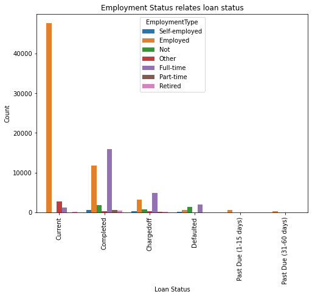

## Borrower APR vs Loan Original Amount

> Borrower APR is inversely proportional to the Loan Original Amount. This is proven by the negative correlation between Borrower APR and Loan Original Amount. A Borrower APR decreases as the Loan Original Amount increases. Most of the loan original amount between 1000 and 15,000 are possessed by borrowers with higher Annual Percentage Rate(APR).

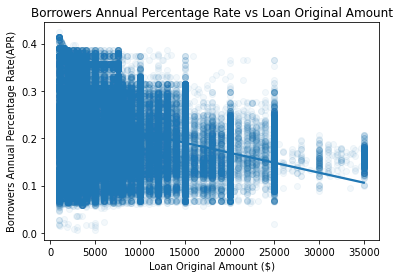

## Borrower Rate vs Loan Original Amount

> Also, there is a negative correlation between Borrower's Rate and the Loan Original Amount. Borrower's Rate decreases as the Loan Original Amount increases. It is observed most of the loans with loan original amount between 1000 and 13,000 are possessed by borrowers with higher Rate.

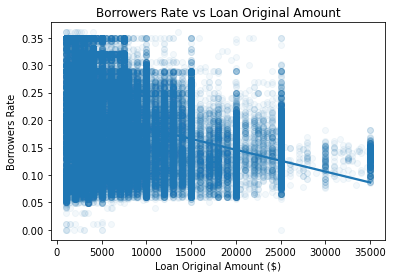

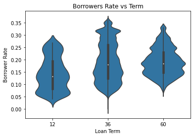

## Borrower APR by Loan Original Amount and Term

> The visualization below shows higher distributution on term 36 and term 60. There are indications of points on higher amounts collected exceeding 25,000 dollars. Term 12 has indications of amounts limited at 25,000 dollars. As the term increased to 36 and 60, Loan original amount was indicated at 35,000 dollars. Term 60 has a denser distribution at 35,000 as compared term 36.

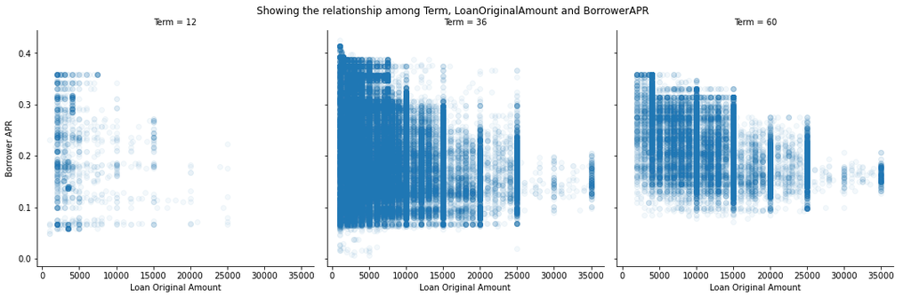